# Ford GoBike Data Visualization

## by Gamal Mashali

## Investigation Overview

> This presentation aimed to present the insights founds in the analyzing of the Ford GoBike data. and I will focus on the difference in usage for customers and subscribers.

## Dataset Overview

> This project analyzes the data collected about individual rides made in a bike-sharing system covering the greater San Francisco Bay area. This dataset consists of data about all monthes of 2018 and some monthes of 2019 .it is avalibale on this link : https://s3.amazonaws.com/fordgobike-data/index.html

## The distribution of user type

> As shown in the next chart, The majority of the users are subscribers, at 88%, and only 12% are customers.

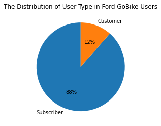

## The distribution of gender

> In the next chart, The majority of the members are Male, at 74%.

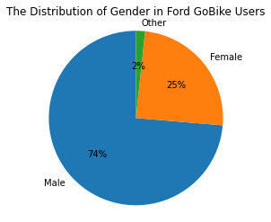

## Usage of the Bikeshare System per User Type and Gender, based on Weekday

> As shown in the next chart, While there is less female and other gender usage than male, the trend between customers and subscribers of each gender is similar. Customers of all genders use the service more often on the weekends, while subscribers use the system during the week, predominately.

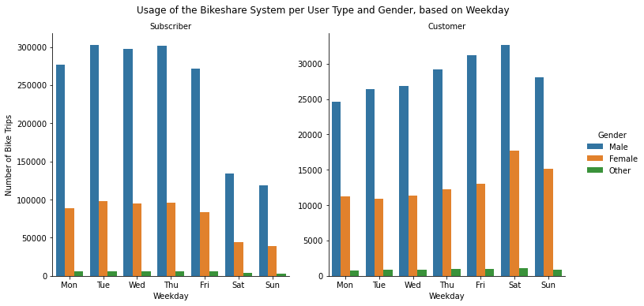

## Monthly Usage of the Bikeshare System per User Type and Gender

Again, we find that each gender follows a similar pattern to the other genders. The summer months are not as popular for customers or subscribers, and usage increases as the winter and spring occur.

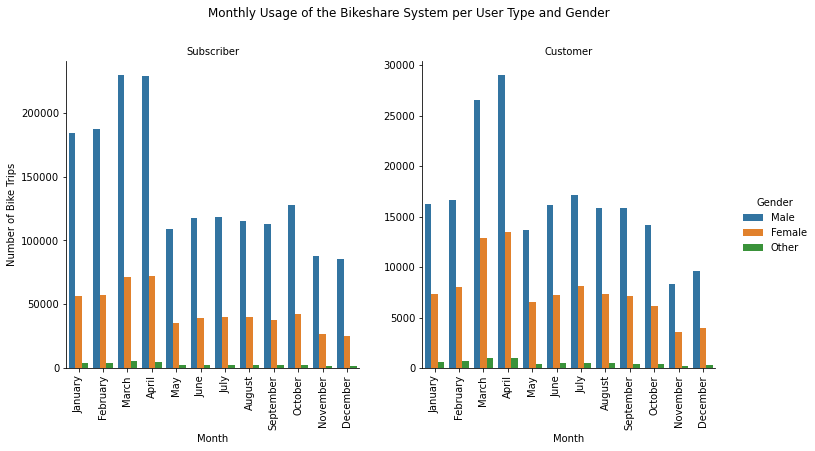

```
[NbConvertApp] Converting notebook slide.ipynb to slides
[NbConvertApp] Writing 675146 bytes to slide.slides.html
```